# Example Hands on 1

# Hands-on 1: Introduction to R tools

Check out the basics of Rmarkdown at the website of [Rstudio](https://rmarkdown.rstudio.com/lesson-1.html).

## Part II: Phyloseq data structure

- **Load example data** of the two-week [diet swap study](http://dx.doi.org/10.1038/ncomms7342) between western (USA) and traditional (rural Africa) diets from [microbiome R package](https://microbiome.github.io/tutorials/Data.html). The example data sets are already in the [phyloseq format](http://joey711.github.io/phyloseq/import-data). R provides many readily available tools to handle and analyze taxonomic profiling data that is provided in this format.

```r
# before I load the data I load tidyverse. It includes ggplot
# and dplyr which are great for data manipulation and visualization
library(tidyverse)

# load data
library(microbiome)
data(dietswap)
print(dietswap)
```

```
## phyloseq-class experiment-level object
## otu_table()   OTU Table:         [ 130 taxa and 222 samples ]
## sample_data() Sample Data:       [ 222 samples by 8 sample variables ]
## tax_table()   Taxonomy Table:    [ 130 taxa by 3 taxonomic ranks ]
```

```r
# rename the example data
pseq <- dietswap
```

- **Microbal abundances / OTU Table** retrieve the microbial (OTU) abundance table from the example data set (phyloseq object). This example data set has abundances at the genus level instead of OTU level. The taxonomic groupings in this 16S data set are only approximations to exact genus-level taxonomic classifications. Tip: microbiome::abundances or phyloseq::otu_table

**Note** that I use the pipe operator (%>%) below. This operator basically takes the output of the first expression and passes it to the next function. See [here](https://www.datacamp.com/community/tutorials/pipe-r-tutorial) for more about the pipe operator (you can skip to *Why Use It* to get the main idea).

```r
# full tables of abundances
otu.absolute <- abundances(pseq)
# or
#otu.absolute <- otu_table(pseq)

# abundances results in a matrix object
abundances(pseq) %>% class()
```

```
## [1] "matrix"
```

```r
otu_table(pseq) %>% class()
```

```
## [1] "otu_table"
## attr(,"package")
## [1] "phyloseq"
```

```r
# print only 5 genera and first 10 samples
kable(otu.absolute[1:5,1:10])
```

|  | Sample-1 | Sample-2 | Sample-3 | Sample-4 | Sample-5 | Sample-6 | Sample-7 | Sample-8 | Sample-9 | Sample-10 |
| --- | --- | --- | --- | --- | --- | --- | --- | --- | --- | --- |
| Actinomycetaceae | 0 | 1 | 0 | 1 | 0 | 0 | 0 | 0 | 0 | 0 |
| Aerococcus | 0 | 0 | 0 | 0 | 0 | 0 | 0 | 0 | 0 | 0 |
| Aeromonas | 0 | 0 | 0 | 0 | 0 | 0 | 0 | 0 | 0 | 0 |
| Akkermansia | 18 | 97 | 67 | 256 | 21 | 16 | 26 | 30 | 19 | 125 |
| Alcaligenes faecalis et rel. | 1 | 2 | 3 | 2 | 2 | 2 | 2 | 2 | 2 | 7 |

- **OTU tables** Retrieve the OTU table and investigate:
1. How many different samples and genus-level groups this phyloseq object has?
2. What is the maximum abundance of Akkermansia in this data set? Tips: see data operations in the [microbiome tutorial](https://microbiome.github.io/tutorials/)

```r
# 1
dim(otu.absolute) # 130 genera (rownumber) and 222 samples (column number)
```

```
## [1] 130 222
```

```r
# 2
otu.absolute["Akkermansia", ] %>% max()
```

```
## [1] 2627
```

- Draw a histogram of library sizes (total number of reads per sample). You can use the readcount function, or count the sum of reads per sample by using the colSums command applied on the otu table abundances. The key idea is that different samples may have different bacterial load. Check [Vandeputte et al. 2017](https://www.nature.com/articles/nature24460) for further discussion on the differences between absolute and relative quantification of microbial abundances.

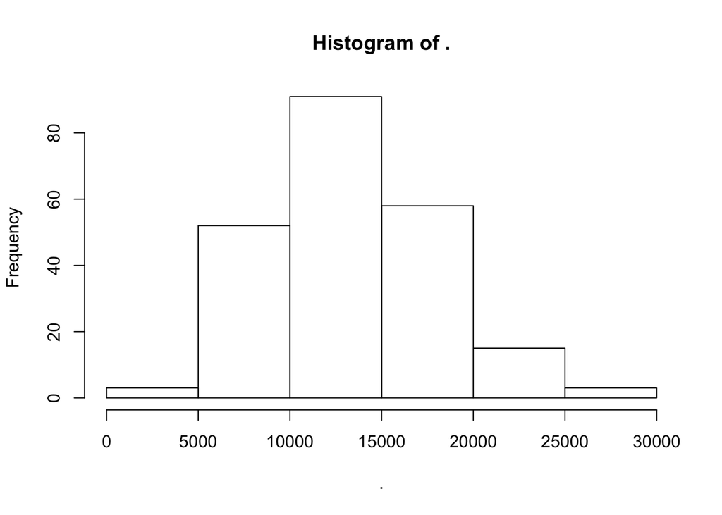

```r
# option 1
pseq %>% readcount() %>% hist()
```

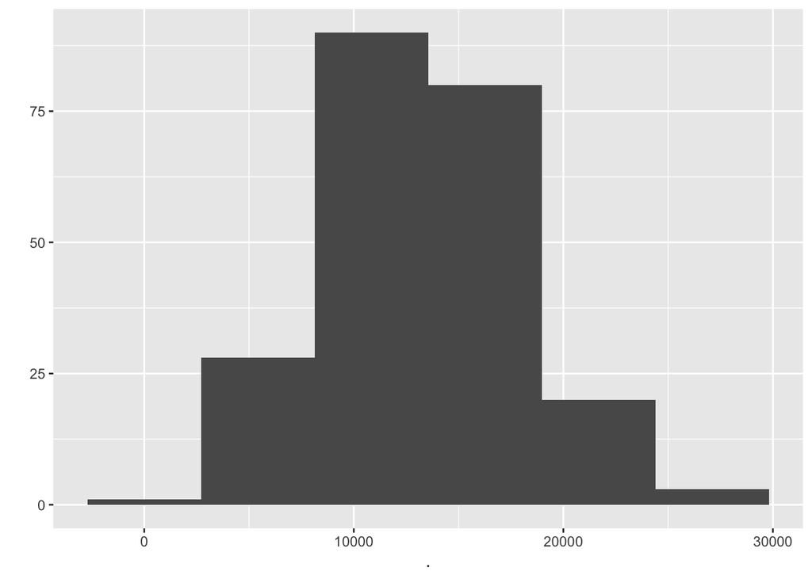

```r
# same using ggplot
pseq %>% readcount() %>% qplot(bins = 6)
```

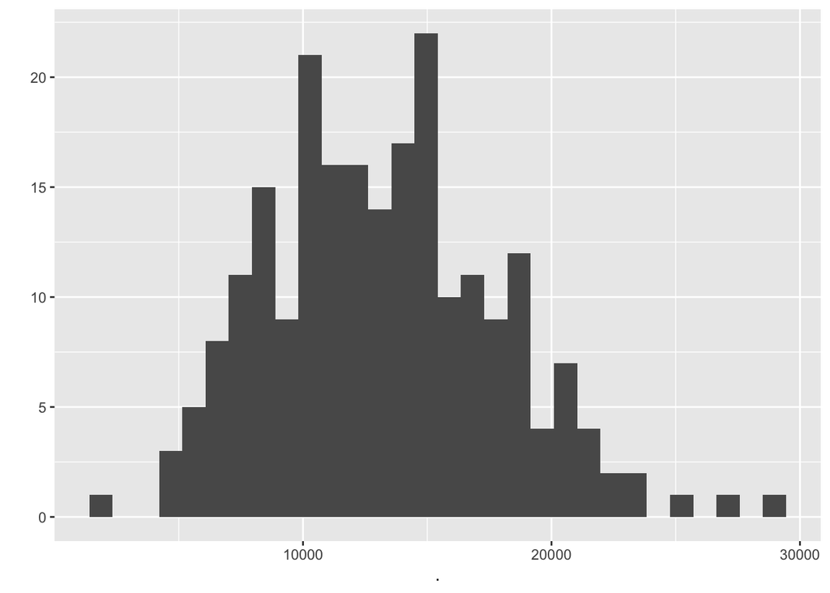

```r
# same using ggplot with different binsize
pseq %>% readcount() %>% qplot(bins = 30)
```

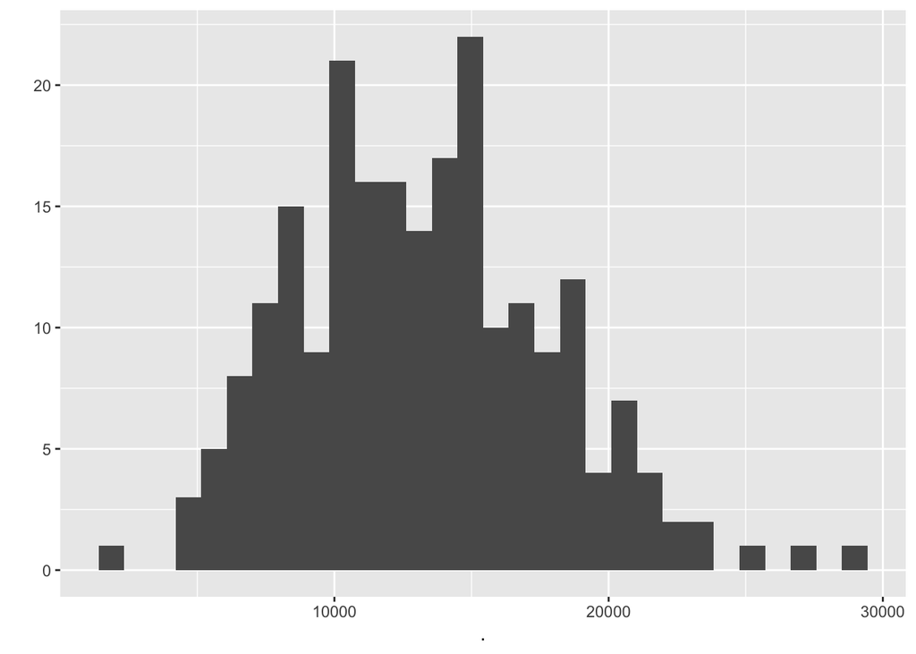

```r
# option 2 using colSums
otu.absolute %>% colSums() %>% qplot(bins = 30)
```

- **Taxonomy table** Retrieve the taxonomy table and print out the first few lines of it with the R command head(). Investigate how many different phylum-level groups this phyloseq object has? Tips: phyloseq::tax_table and unique.

```r
# print first few lines
pseq %>%
  tax_table() %>%
  head() %>%
  kable()
```

|  | Phylum | Family | Genus |
| --- | --- | --- | --- |
| Actinomycetaceae | Actinobacteria | Actinobacteria | Actinomycetaceae |
| Aerococcus | Firmicutes | Bacilli | Aerococcus |
| Aeromonas | Proteobacteria | Proteobacteria | Aeromonas |
| Akkermansia | Verrucomicrobia | Verrucomicrobia | Akkermansia |
| Alcaligenes faecalis et rel. | Proteobacteria | Proteobacteria | Alcaligenes faecalis et rel. |
| Allistipes et rel. | Bacteroidetes | Bacteroidetes | Allistipes et rel. |

```r
# how many different phylum-level groups?

# option 1
tax_table(pseq)[, 1] %>%
    unique() %>%
    length()
```

```
## [1] 8
```

```r
# option 2
pseq %>%
  tax_table() %>%
  as.data.frame() %>% # we convert the matrix to a data frame for the next step
  distinct(Phylum) %>% # select only unique Phyla
  dim() # count
```

```
## [1] 8 1
```

- **Sample metadata** Retrieve sample metadata. How many unique subjects this data set has? What is the male/female ratio? Draw a bar plot of subject BMI-group. Tips: microbiome::meta

```r
# option 1 (results in dataframe)
pseq.meta <- meta(pseq)
# option 2
# pseq.meta <- sample_data(pseq)

# number of unique subjects
pseq.meta$subject %>%
  unique() %>%
  length()
```

```
## [1] 38
```

```r
# male/female ratio (of samples)
sex.count <- pseq.meta %>%
  select(sex) %>%
  group_by(sex) %>%
  summarise(n = n())

# take a look at the table
kable(sex.count)
```

| sex | n |
| --- | --- |
| female | 102 |
| male | 120 |

```r
sex.count[sex.count$sex == "male", "n"]/sex.count[sex.count$sex == "female", "n"]
```

```
##          n
## 1 1.176471
```

```r
# male/female ratio (of subjects)
sex.count <- pseq.meta %>%
  filter(timepoint == 1) %>% # to only count each subject once
  group_by(sex, subject) %>%
  summarise(n = n())
dim(sex.count[sex.count$sex == "male", ])[1] / dim(sex.count[sex.count$sex == "female", ])[1]
```

```
## [1] 1.235294
```

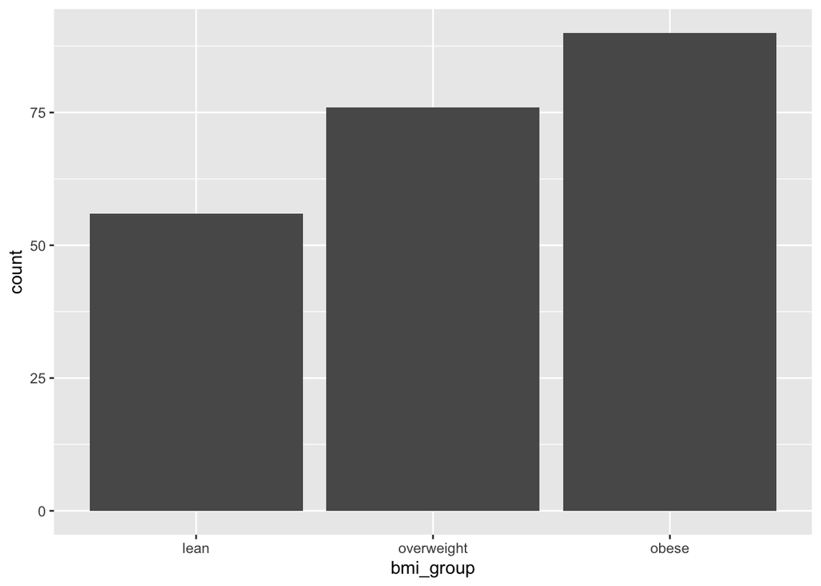

```r
# barplot of BMI
ggplot(pseq.meta, aes(bmi_group)) +
  geom_bar()
```

## Part III: Data manipulation and exploration

- **Subsetting** Pick a subset of the phyloseq object including only male and obese individuals. How many there are? Tips: subset_samples

```r
pseq.obe <- subset_samples(pseq, bmi_group == "obese" & sex == "male")
meta(pseq.obe) %>% dim() # there are 30 samples
```

```
## [1] 30  8
```

```r
meta(pseq.obe) %>% filter(timepoint == 1) %>% dim() # and 5 subjects
```

```
## [1] 5 8
```

- **Transformations** The phyloseq data has absolute abundances. Use the microbiome::transform command to convert these into relative abundances. Compare Akkermansia abundance using the example data before and after the compositionality transformation (with a cross-plot, for instance). Finally, compare the results to CLR- transformed data (see e.g. [Gloor et al. 2017](https://www.frontiersin.org/articles/10.3389/fmicb.2017.02224/full))

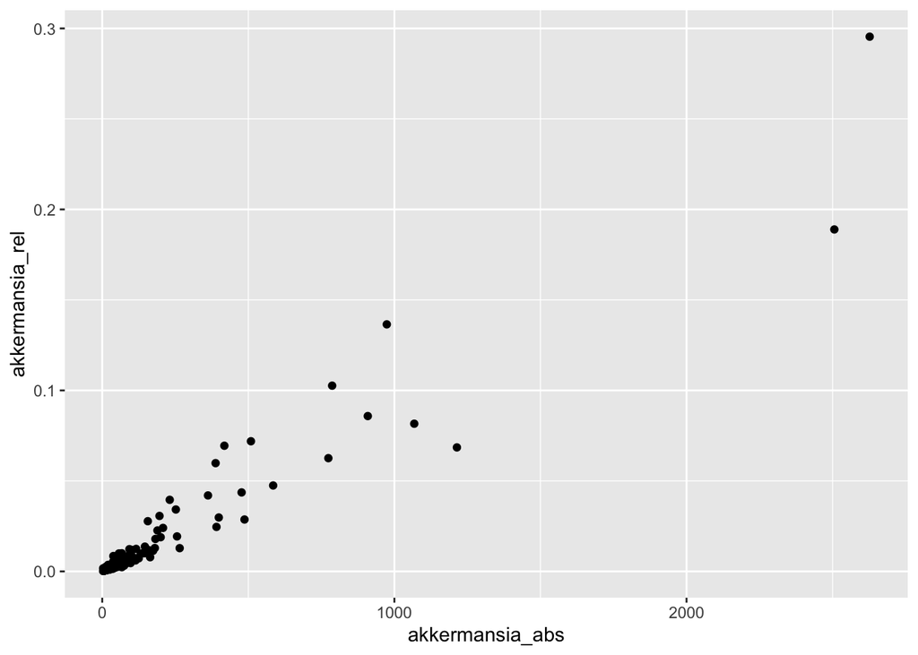

```r
# relative abundance
pseq.rel <- microbiome::transform(pseq, transform = "compositional")
# clr transformed abudnances
pseq.clr <- microbiome::transform(pseq, transform = "clr")

# now extract akkermansia from each object
akkermansia.absolute <- otu.absolute %>%
  t() %>%
  as.data.frame() %>%
  rownames_to_column("sample_id") %>%
  select(sample_id, akkermansia_abs = Akkermansia)

akkermansia.relative <- abundances(pseq.rel) %>%
  t() %>%
  as.data.frame() %>%
  rownames_to_column("sample_id") %>%
  select(sample_id, akkermansia_rel = Akkermansia)

akkermansia.clr <- abundances(pseq.clr) %>%
  t() %>%
  as.data.frame() %>%
  rownames_to_column("sample_id") %>%
  select(sample_id, akkermansia_clr = Akkermansia)

# for the crossplot I combine the abundances into one dataframe
akkermansia <- left_join(
    akkermansia.absolute,
    akkermansia.relative,
    by = "sample_id") %>%
  left_join(akkermansia.clr, by = "sample_id")

# absolute versus relative
ggplot(akkermansia, aes(akkermansia_abs, akkermansia_rel)) +
  geom_point()
```

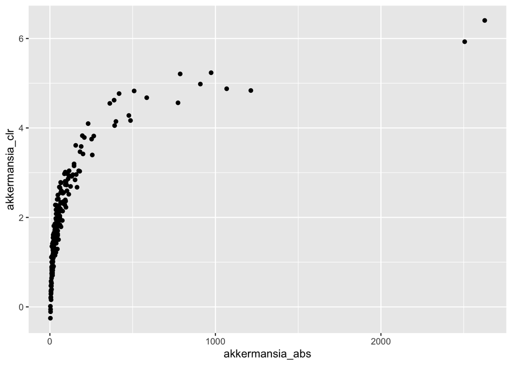

```r
# absolute versus clr
ggplot(akkermansia, aes(akkermansia_abs, akkermansia_clr)) +
  geom_point()
```

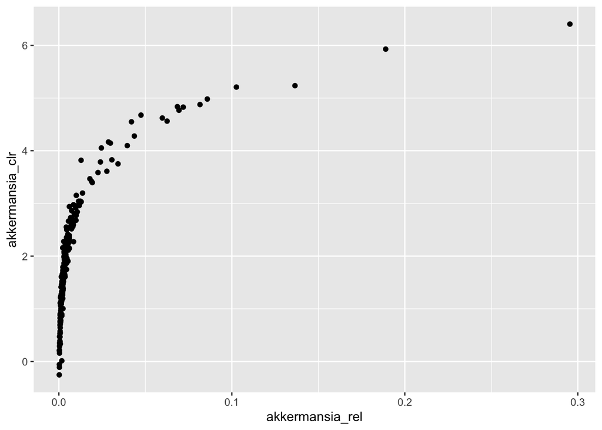

```r
# relative vs clr
ggplot(akkermansia, aes(akkermansia_rel, akkermansia_clr)) +
  geom_point()
```

- **Visual exploration** Visualize the population distribution of abundances for the following taxa: Akkermansia, Dialister, Gemella. Do the same for CLR-transformed abundances. Tip: microbiome::plot_density / microbiome::transform

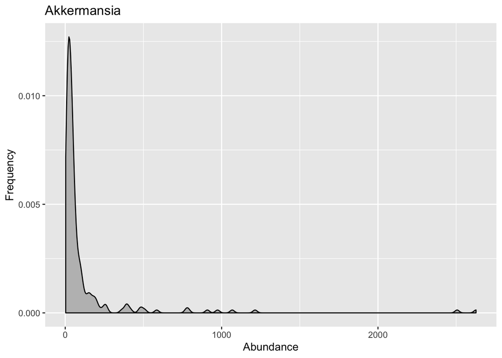

```r
# option 1: use the function individually for each genus, e.g.:
plot_density(pseq, variable = "Akkermansia")
```

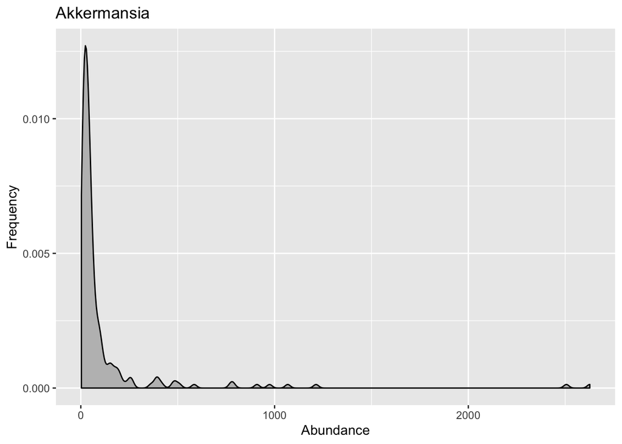

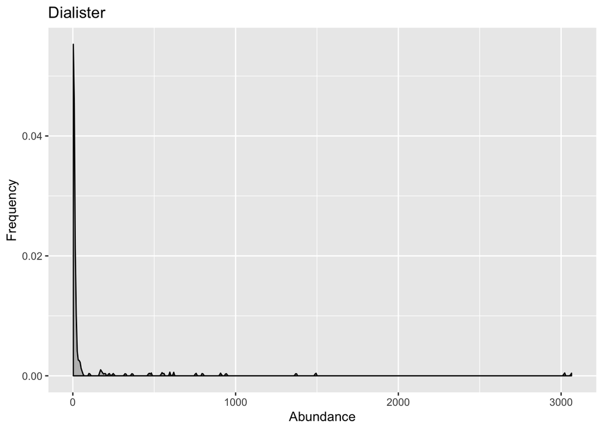

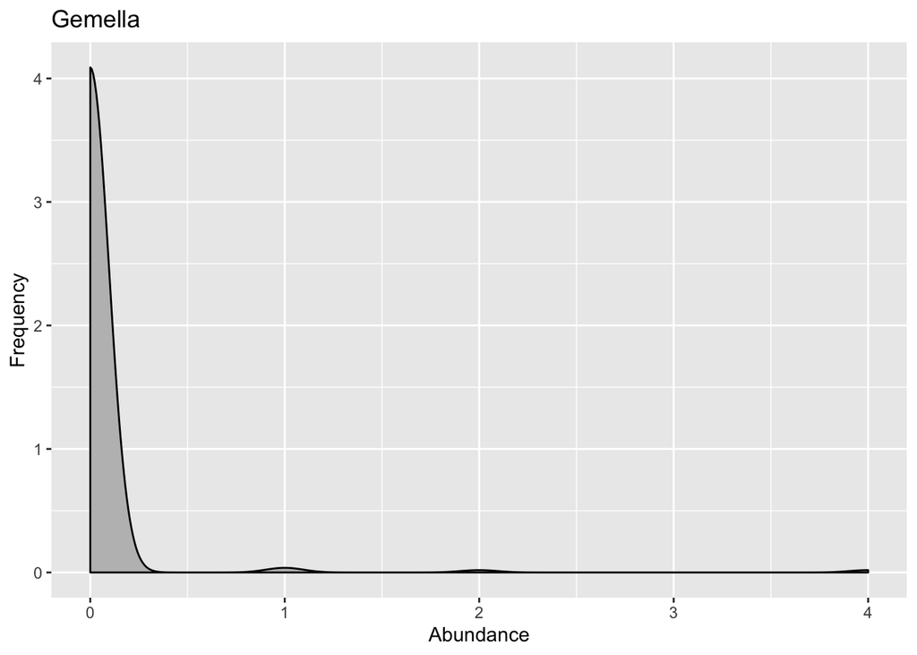

```r
# option 2: use the map function over a vector:
otus <- c("Akkermansia", "Dialister", "Gemella")
map(otus, ~plot_density(pseq, variable = .x))
```

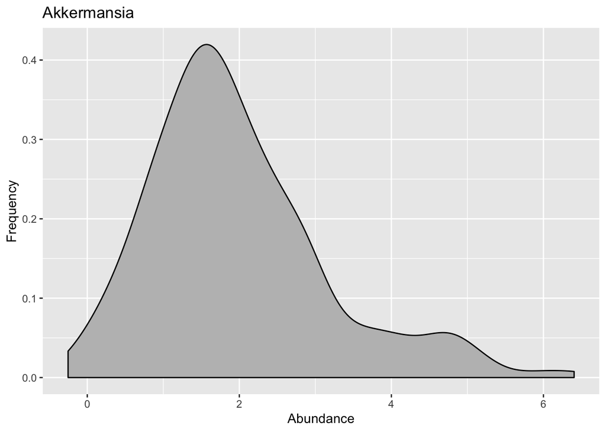

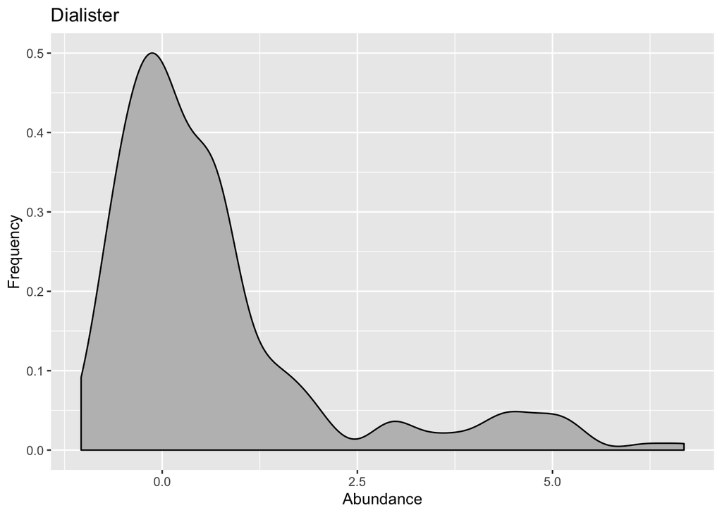

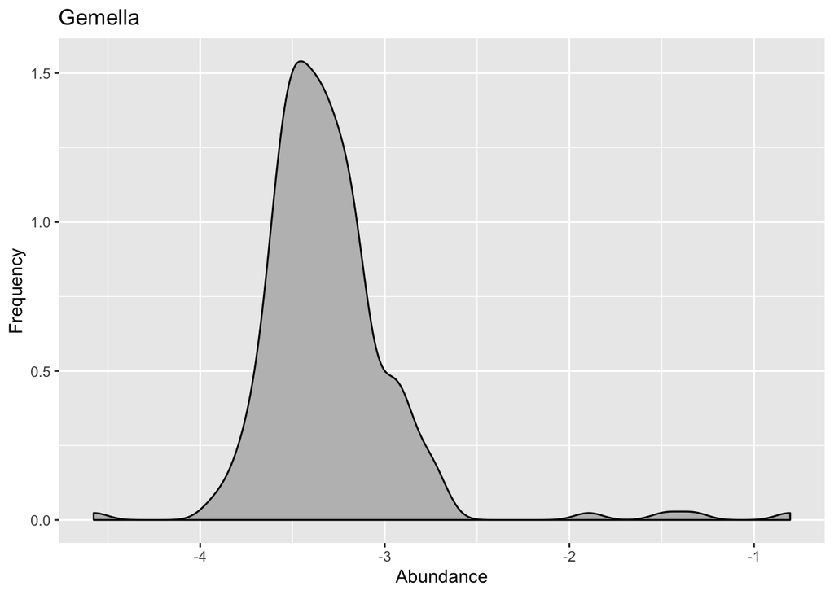

```r
# same for the CLR transformed:
map(otus, ~plot_density(pseq.clr, variable = .x))
```

- Experiment with other [phyloseq data manipulation tools](https://microbiome.github.io/tutorials/Preprocessing.html)